# Defensive Programming: How to (Help) Shield Your Code From Error

Michael Bertolacci michael_bertolacci@uow.edu.au Centre for Environmental Informatics, UOW, Australia

2021-07-06

## Who I am

A postdoc at the University of Wollongong, working on applied spatio-temporal statistical problems with Noel Cressie and Andrew Zammit-Mangion.

Before that, I was a PhD student at the University of Western Australia.

**Before that, I was a software engineer for 10 years.**

## Assumed programming knowledge

- You have programmed before.
- You can read basic R or Python.

If you’re at an earlier stage and want to learn more about these, see Danielle Navarro’s great textbook [1] or the R for Data Science book [2].

## ⚠️ Warning ⚠️

This tutorial is rather informal and unscholarly. It is full of opinions and observations from my own experience.

The hope is to provoke discussion on good coding practices within this community.

Please share your thoughts, opinions, rants, etc. in Slack at any time!

We will stop for questions and discussion a few times.

## Motivation

[figure not shown]

There are several things that can (should?) keep a statistician from falling asleep at night.

One of those is Simpson’s paradox:

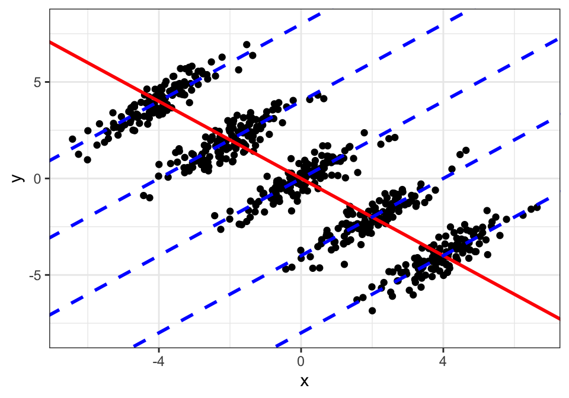

**Another is having bugs 🐞 in your code.**

## Story time 📊 🐞

Reinhart, C, M.; Rogoff, K. S. (2010). Growth in a Time of Debt. *American Economic Review*. 100 (2): 573–78. doi:10.1257/aer.100.2.573.

Their conclusions led several governments to implement financial austerity programs.

A student reproducing the work found that they’d made an error in a formula in their Excel spreadsheet, invalidating some of their empirical claims.

## Story time

My first research project…

## Your stories and a poll

If you’ve had a similar experience, feel free to share it in the Slack chat and we can discuss it a bit later.

🗳️ Now let’s just run a quick poll… 🗳️

## Peer review: the crown jewel of science 👑

We peer review each other’s work prior to publication.

- Keeps us honest
- Encourages rigour
- Ensures the work is useful
- **Catches errors**

But it generally only applies to the written part of the work. If the numbers reported look plausible, there’s (usually) an assumption that they are computed correctly.

Code is a blind spot for peer review.

## How big is the blind spot?

It’s hard to be objective about this, but take two examples:

- One (short) chapter of my PhD thesis:
  - Lines of LaTeX: ~300
  - Lines of code: ~1,400 - **4.5x more**
- Paper submitted based on a longer chapter:
  - Lines of LaTeX: ~1000
  - Lines of code: ~13,000 - **13x more**

Bugs aren’t just a problem in academic work. Professional software developers invest huge effort into avoiding and fixing bugs.

Some gold standard strategies the best teams use:

- **Peer review**: software is not released until the code has been read by multiple people
- **Dedicated testing teams**: you can get paid to break code, all day! https://www.seek.com.au/software-tester-jobs

Most academics don’t get to use these strategies…

There are some strategies that an individual programmer can use, *right now*.

We’ll cover three:

- **Strategy 1: Make your code easier to understand**
- **Strategy 2: Defensive programming**
- **Strategy 3: Automated testing**

## Every bug can be traced back to a wrong assumption.

The person who wrote the code made the assumption.  
⇒ You wrote the code.  
⇒ **You caused the bug :(**

What you need are ways to:

- *Make your assumptions more obvious* so you avoid making wrong ones (Strategy 1).
- *Make it so you know when an assumption is violated* so you can find and fix the error (Strategies 2 and 3).

# Strategy 1: Make your code easier to understand

Code that is hard to read is hard to understand.

You should strive to make your code clean and readable.

This helps:

- **You** now, when you debug the code
- **You** in the future when you read the code
- **Everyone** who reads the code

## The DRY principle

Don’t Repeat Yourself.

$$\textrm{RMS}(x_1, \ldots, x_n) = \sqrt{\frac{1}{n} \sum_{i = 1}^n x_i^2}$$

```python
rms1 = np.sqrt(np.mean(
  np.square(error1)
))
rms2 = np.sqrt(np.mean(
  np.square(error2)
))
```

```python
def rms(x):
    '''Return the root mean square of
    the vector x'''
    return np.sqrt(np.mean(
      np.square(x)
    ))


rms1 = rms(error1)
rms2 = rms(error2)
```

## Follow a style guide

Style guides list rules to follow when laying out your code.

You should start from a publicly available guide.

**For R, you can follow the Tidyverse style guide [3].**

**For Python, the standard is called PEP 8 [4].**

You can tweak the guidelines to suit you, but not following some style guide is like writing a paper with inconsistent grammar, or using two different citation styles in the same document (Bertolacci, 2020).

## R style example

Non-compliant:

```r
y <- x*2
if(y > 2) {
  z <- y + 2
}
sqrt_z <- sqrt (z)
```

Compliant:

```r
y <- x * 2
if (y > 2) {
  z <- y + 2
}
sqrt_z <- sqrt(z)
```

The R package [`lintr`](https://github.com/jimhester/lintr) [5] can check your code automatically:

```
example.R:1:7: style: Put spaces around all infix operators.
y <- x*2
     ~^~
example.R:2:3: style: Place a space before left parenthesis, except in a function call.
if(y > 2) {
  ^
example.R:5:11: style: Remove spaces before the left parenthesis in a function call.
sqrt_z <- sqrt (z)
```

## Python style example

Non-compliant:

```python
y = x*2
if y> 2:
   z = y + 2
sqrt_z = sqrt (z)
```

Compliant:

```python
y = x * 2
if y > 2:
    z = y + 2
sqrt_z = sqrt(z)
```

The program [pycodestyle](https://pypi.org/project/pycodestyle/) [6] checks if you are following the rules:

```
example.py:2:5: E225 missing whitespace around operator
example.py:3:4: E111 indentation is not a multiple of four
example.py:4:14: E211 whitespace before '('
```

Sometimes you knew what the code does when you wrote it, but a few months later…

```r
loc<-c(137.5, -4.7)
loc2<-c(77.5, 18.1)
dat<-read.csv('locations.csv')
d=2*3389.5*asin(sqrt(
sin((dat$lat*pi/180-loc[2]*pi/180)/2)^2
+cos(dat$lat*pi/180)*cos(loc[2]*pi/180)
*sin((dat$lon*pi/180-loc[1]*pi/180)/2)^2))
d2=2*3389.5*asin(sqrt(
sin((dat$lat*pi/180-loc2[2]*pi/180)/2)^2
+cos(dat$lat*pi/180)*cos(loc2[2]*pi/180)
*sin((dat$lon*pi/180-loc2[1]*pi/180)/2)^2))
#dat$nrst=-1
dat$nrst=0
for(i in 1:nrow(dat)){
if(d[i]<d2[i])
dat$nrst[i]<-1
else
dat$nrst[i]<-2
}
```

```r
MARS_RADIUS <- 3389.5  # in kilometres

hav_deg <- function(x) sin(x * pi / 360) ^ 2
cos_deg <- function(x) cos(x * pi / 180)
mars_haversine_dist <- function(locations, origin) {
  with(locations, {
    2 * MARS_RADIUS * asin(sqrt(
      hav_deg(latitude - origin['latitude'])
      + cos_deg(latitude) * cos_deg(origin['latitude'])
      * hav_deg(longitude - origin['longitude'])
    ))
  })
}

curiosity_location <- c(longitude = 137.5, latitude = -4.7)
perseverance_location <- c(longitude = 77.5, latitude = 18.1)

locations <- read.csv('locations.csv')
curiousity_dist <- mars_haversine_dist(locations, curiosity_location)
perseverance_dist <- mars_haversine_dist(locations, perseverance_location)

locations$nearest_rover <- 'none'
for (i in 1 : nrow(locations)) {
  if (curiousity_dist[i] < perseverance_dist[i]) {
    locations$nearest_rover[i] <- 'curiousity'
  } else {
    locations$nearest_rover[i] <- 'perseverance'
  }
}
```

## Comments

**A rule of thumb:** Comments in code should say *what* your code does, not explain *how*.

Unhelpful:

```r
mars_haversine_dist <- function(
  locations,
  origin
) {
  # Take two times the radius times
  # the arcsine of the square root
  # of ...
  ...
}
```

Helpful:

```r
# Calculate the distance in
# kilometres between two coordinates
# on Mars
mars_haversine_dist <- function(
  locations,
  origin
) {
  ...
}
```

The code should be clean enough that the *how* is obvious.

(I break this rule around 10% of the time.)

## Long functions

**A rule of thumb**: functions should fit on one or two screenfuls.

> The maximum length of a function is inversely proportional to the complexity and indentation level of that function. So, if you have a conceptually simple function that is just one long (but simple) case-statement, where you have to do lots of small things for a lot of different cases, it’s OK to have a longer function.  
> - Linus Torvalds [7]

(I break this rule around 10% of the time)

## Long files

You should also organise your code into multiple well-named files.

**A rule of thumb**: code files should not be too long, say no longer than 1000-2000 lines.

(I break this rule less often.)

## More clean code tips

- Code for correctness and readability first.
- Shorter isn’t necessarily better—short programs don’t run any faster!
- Tab completion in your editor means you don’t have to type longer function and variable names every time.
- Picking good names for things is hard, but it’s worth the effort.

## Discussion on clean code 🗣️

Questions? Comments? Disagreements?

**Feel free to add your own clean code tips to Slack!**

Or raise your hand in the Zoom chat. ✋

# Strategy 2: Defensive programming…

…or, dead programs tell no lies [8].

## A tale of two errors…

```r
n <- length(y)
sigma <- 1
log_likelihood <- (
  - n * log(2 * pi) / 2
  - n * log(sigma)
  - sum(y ^ 2 / sigma ^ 2) / 2
)
bic <- log(n) - 2 * log_likelihood
print(bic)
```

```
## [1] NA
```

No explicit error, but you probably don’t want that value to be `NA`. What’s the root cause?

```r
dat <- data.frame(x = 1 : 10)
dat$y <- sin(df$x)
fit <- lm(y ~ x, data = dat)
print(coef(fit))
plot(dat$x, fitted(dat$y))
```

```
## Error in df$x: object of type
##   'closure' is not subsettable
```

Explicit error; annoying, but offending line is obvious.

## Dead programs tell no lies

Defensive programming can be used when you’re aware you’re making an assumption. The idea is to intentionally throw an error when an assumption found to be false.

Most languages have functions to help you do this.

**This way, you don’t have to search for the offending line.**

Example: the exponential covariance function,

$$C(\mathbf{x}, \mathbf{x}') \equiv \exp\left( -\frac{||\mathbf{x} - \mathbf{x}'||}{l} \right)$$

where $l > 0$.

In R, you can use the **`stopifnot`** function:

```r
# Given a vector or matrix x, return the covariance matrix based on the
# exponential covariance function
cov_exponential <- function(x, length_scale) {
  stopifnot(length_scale > 0)
  exp(-fields::rdist(x) / length_scale)
}

cov_exponential(y, -1)
```

```
## Error in cov_exponential(y, -1): length_scale > 0 is not TRUE
```

In Python, you can use the **`assert`** keyword:

```python
import numpy as np

def cov_exponential(x, length_scale):
    '''Given a vector or matrix x, return the covariance matrix based on the
    exponential covariance function'''
    assert length_scale > 0, 'length_scale must be positive'
    return np.exp(-np.linalg.norm(x) / length_scale)

cov_exponential(y, -1)
```

```
Traceback (most recent call last):
  File "example.py", line 7, in <module>
    cov_exponential(y, -1)
  File "example.py", line 4, in cov_exponential
    assert length_scale > 0, 'length_scale must be positive'
AssertionError: length_scale must be positive
```

## Back to the tale of two errors

```r
stopifnot(all(!is.na(y)))
n <- length(y)
sigma <- 1
log_likelihood <- (
  - n * log(2 * pi) / 2
  - n * log(sigma)
  - sum(y ^ 2 / sigma ^ 2) / 2
)
bic <- log(n) - 2 * log_likelihood
print(bic)
```

```
## Error: all(!is.na(y)) is not TRUE
```

## More defensive programming tips

- You won’t always know what assumptions you’re making implicitly immediately.
- But! when your code breaks, add a `stopifnot` or `assert` to catch it next time.
- Don’t feel the need to check *everything*, just the most important parts.
- In R, the `assertthat` package [9] can help.

## Discussion on defensive programming 🗣️

Questions? Comments? Disagreements?

**Feel free to add your own defensive programming tips to Slack!**

Or raise your hand in the Zoom chat. ✋

(But note that we will talk about a related topic, automated testing, very soon.)

# Strategy 3: Automated testing

Defensive programming actively tests your assumptions when the code is running.

Automated testing goes one step further: you write code that calls your code, actively probing for problems.

`add_one.py`:

```python
def add_one(x):
  '''Returns the argument, plus one'''
  return x + 1.1
```

`test_add_one.py`:

```python
from add_one import add_one

def test_add_one():
  assert add_one(1) == 2
```

Running the tests:

```
======================= test session starts ========================
collected 1 item

test_add_one.py F                                            [100%]
============================= FAILURES =============================
___________________________ test_add_one ___________________________

    def test_add_one():
>     assert add_one(1) == 2
E     assert 2.1 == 2
E      +  where 2.1 = add_one(1)

test_add_one.py:4: AssertionError
===================== short test summary info ======================
FAILED test_add_one.py::test_add_one - assert 2.1 == 2
=================== 1 failed, 0 passed in 0.15s ====================
```

## What makes for a good set of tests?

- Each test tests one thing at a time
- Tests are short and simple; don’t test too many things
- Boundary conditions are tested
- All code lines are explored

```python
def max_one(x):
  '''Return the maximum between the argument and one'''
  if x < 1:
    return 1
  else:
    return x

def test_max_one():
  assert max_one(0) == 1  # First code path
  assert max_one(1) == 1  # Boundary condition
  assert max_one(2) == 2  # Second code path
```

`covariance.py`:

```python
import numpy as np

def cov_exponential(x, length_scale):
    '''Given a vector or matrix x, return the covariance matrix based on the
    exponential covariance function'''
    assert length_scale > 0, 'length_scale must be positive'
    return np.exp(-np.linalg.norm(x) / length_scale)
```

`test_covariance.py`:

```python
import pytest
import numpy as np

from covariance import cov_exponential

def test_cov_exponential():
    assert cov_exponential([0, 0], 1) == 1.0
    assert cov_exponential([0, 1], 1) == np.exp(-1)
    assert cov_exponential([0, 1], 2) == np.exp(-1 / 2)
    with pytest.raises(AssertionError):
        cov_exponential([0, 0], -1)
```

## Testing in Python and R

The preceding Python examples use the **`pytest`** framework [10]. Tests go into files with names starting with “`test_`”

In R, you can use the testthat package [11]

`add_one.R`:

```r
add_one <- function(x) {
  x + 1.1
}
```

`test_add_one.R`:

```r
source('add_one.R')
context('add_one')

test_that('adding one to one makes two', {
  expect_equal(add_one(1), 2)
})
```

Running it in an R session:

```
> testthat::test_file('test_add_one.R')

══ Testing test_add_one.R ═════════════════════════════════════════════════
[ FAIL 1 | WARN 0 | SKIP 0 | PASS 0 ]

── Failure (test_add_one.R:8:3): adding one to one makes two ──────────────
add_one(1) not equal to 2.
1/1 mismatches
[1] 2.1 - 2 == 0.1

[ FAIL 1 | WARN 0 | SKIP 0 | PASS 0 ]
```

## Testing an R package

In R you can also test a package. Here are the tests for one of mine, WoodburyMatrix [12]:

```
> devtools::test('WoodburyMatrix')

Testing WoodburyMatrix
✓ |  OK F W S | Context
✓ |  89       | WoodburyMatrix [0.7 s]
✓ |   1       | lints [3.9 s]
✓ |   9       | normal distribution

══ Results ═══════════════════════════════════════════════════════════════
Duration: 4.8 s

[ FAIL 0 | WARN 0 | SKIP 0 | PASS 99 ]
```

Here there are 99 separate checks.

A guide to setting this up is in the R packages book [13].

## Testing and version control

You may have seen these badges on repositories on GitHub:

[figure not shown]

Tests are automatically run when changes to the software are published. The code coverage metric counts how many lines of code in the software are tested.

This is beyond what most small research projects need, but it’s nice to have!

## How to make the most of automated testing

A few thoughts on automated testing:

- Automated testing is helpful when your code is already organised into functions (or packages).
- If a function is hard to test, it might be too complicated anyway. Break it up into smaller functions.
- If you find a bug, write a test for the bug that fails, THEN fix the bug

# Other strategies

- Version control, such as git [14].
- Not reinventing the wheel. If a mature package has a function you need, use that rather than write your own.
- Automated checking for common bugs:
  - The **`pylint`** program can do this for Python [15].
  - The **`lintr`** package does a little bit of this [5].
- To me, most important: Internal peer review:
  - Can a coauthor or a friend **read your code** for you?

# Conclusion

Bugs can taint otherwise great research, and peer review (probably) won’t catch them.

Some easy-to-follow strategies can help you avoid some bugs. Practice makes perfect!

Sadly, though, there will always be more bugs. **If you find a way to avoid them all, please tell me!**

Thanks everyone!

# Discussion 🗣️

That’s the end of the content, now this is space for free form discussion on anything related to the topic of good coding practices.

**Please write your thoughts on Slack**

Or raise your hand in the Zoom chat. ✋

# Resources

[1] Navarro, D. (2021). *Learning Statistics with R*. Published online at https://learningstatisticswithr.com/.  
[2] Wickham, H. and Grolemund, G. (2021). *R for Data Science*. Published online at https://r4ds.had.co.nz/.  
[3] Wickham, H. (2021). *The tidyverse Style Guide*. Published online at https://style.tidyverse.org/.  
[4] van Rossum, G., Warsaw, B., and Coghlan, N. PEP 8—Style Guide for Python Code. https://www.python.org/dev/peps/pep-0008/, last accessed 2021-02-16.  
[5] Hester, J., Angly, F., and Hyde, R. (2020). lintr: A ‘Linter’ for R Code. R package version 2.0.1. https://CRAN.R-project.org/package=lintr.  
[6] Rocholl, J. and Lee, I., and other contributors. pycodestyle—Python Style Guide Checker. https://pypi.org/project/pycodestyle/.  
[7] Torvalds, L. (2016). Linus kernel coding style. https://www.kernel.org/doc/html/v4.10/process/coding-style.html#functions  
[8] Thomas, D., Hunt, A. (2019). *The Pragmatic Programmer: Your Journey to Mastery* (20th ed.). Addison-Wesley Professional, Boston, MA.  
[9] Wickham, H. (2019). assertthat: Easy Pre and Post Assertions. R package version 0.2.1. https://CRAN.R-project.org/package=assertthat.  
[10] Krekel, H., and other contributors (2021). pytest. https://docs.pytest.org/en/stable/.  
[11] Wickham, H. (2011). testthat: Get Started with Testing. The R Journal, vol. 3, no. 1, pp. 5–10.  
[12] Bertolacci, M. (2020). WoodburyMatrix: Fast Matrix Operations via the Woodbury Matrix Identity. https://CRAN.R-project.org/package=WoodburyMatrix.  
[13] Wickham, H., Bryan, J. (2021). *R Packages* (2nd ed.). Published online at https://r-pkgs.org/index.html.  
[14] Hamano, J., Torvalds, L., and other contributors (2021). git. https://git-scm.com/.  
[15] Logilab (2021). pylint. https://www.pylint.org/.